# danjtan_7

Dan Tanner

09 March, 2017

# Exercise 1

*Manipulate the above code to reduce the correlation between X1X1 and X2X2 and recalculate the regression coefficients. Explain what you find.*

```r
set.seed(42)
Y = seq(from=0, to=20, by=0.1)
X3 = (Y-2)/3 + runif(length(Y), min=0.5, max=20)
X4 = (Y+3)/2 + runif(length(Y), min=0.5, max=20)
df.1 = as.data.frame(cbind(Y, X3, X4))
```

I extended the interval from which the random perturbations are drawn to be much larger: (0.5, 20)

```r
summary(lm(Y~X3, data = df.1))$coefficients
```

```
##             Estimate Std. Error  t value     Pr(>|t|)
## (Intercept) 6.747746 0.99683085 6.769199 1.419648e-10
## X3          0.242976 0.06825329 3.559915 4.639757e-04
```

For X3, Y values are selected by random perturbations from the line Y=3X+2. We would expect the X3 estimate value to be around 3, but we end up with ~0.24.

```r
summary(lm(Y~X4, data = df.1))$coefficients
```

```
##             Estimate Std. Error  t value     Pr(>|t|)
## (Intercept) 2.800056 0.94077027 2.976344 3.278809e-03
## X4          0.446528 0.05403402 8.263832 1.964018e-14
```

Similarly for X4 we expected an estimate of around 2, but end up with ~0.44.

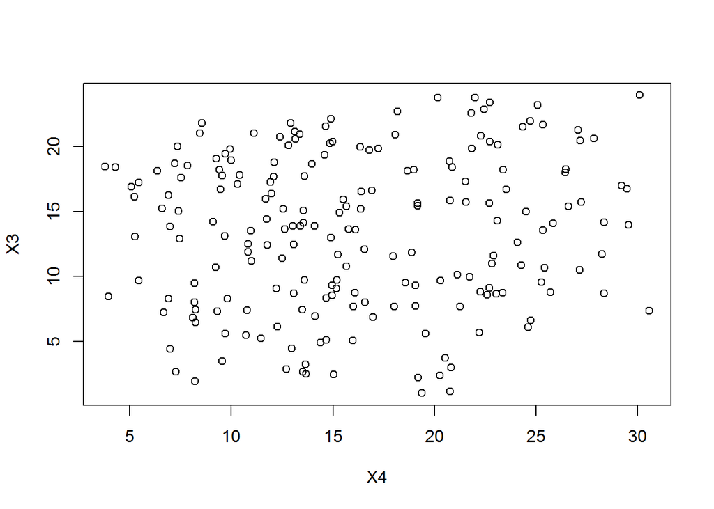

```r
plot(X3~X4)
```

```r
cor(X3, X4)
```

```
## [1] 0.08635012
```

We end up with a low correlation coefficient, which makes sense when we look at the plot. By increasing the magnitude of the random noise, the signal becomes obscured.

# Exercise 2 [Bonus]

*Challenge yourself by calculateing the RSS of the two models, F statistics (1 pt) and the p-value (1 pt) all by yourself (i.e. not using the anova() function).*

```r
mod1 = lm(Temp~Wind, data=airquality)
mod2 = lm(Temp~Wind+Solar.R, data=airquality)

RSS1 <- sum((mod1$residuals)^2)
RSS1
```

```
## [1] 7520.672
```

```r
RSS2 <- sum((mod2$residuals)^2)
RSS2
```

```
## [1] 6979.506
```

```r
p1 <- 2
p2 <- 3
n <- nrow(airquality)
F <- ( ((RSS1 - RSS2) / (p2 - p1)) / (RSS2 / (n - p2)) )
F
```

[output not shown]

```r
pval <- (1-pf(F, p2-p1, n-p2))
pval
```

[output not shown]

Comparing these values to those below, we see that we get the same numbers:

```r
anova(mod1, mod2)
```

```
## Analysis of Variance Table
##
## Model 1: Temp ~ Wind
## Model 2: Temp ~ Wind + Solar.R
##   Res.Df    RSS Df Sum of Sq      F   Pr(>F)
## 1    109 7520.7
## 2    108 6979.5  1    541.17 8.3739 0.004606 **
## ---
## Signif. codes:  0 '***' 0.001 '**' 0.01 '*' 0.05 '.' 0.1 ' ' 1
```

# Exercise 2

*Compare a third model (mod3) with ozone variable as the third independent variable to mod1 and mod2 above. Does it explain more variance? Does it give you reasonable estimate of regression coefficients?*

```r
mod3 = lm(Temp~Wind + Solar.R + Ozone, data=airquality)

anova(mod1, mod2, mod3)
```

```
## Analysis of Variance Table
##
## Model 1: Temp ~ Wind
## Model 2: Temp ~ Wind + Solar.R
## Model 3: Temp ~ Wind + Solar.R + Ozone
##   Res.Df    RSS Df Sum of Sq      F    Pr(>F)
## 1    109 7520.7
## 2    108 6979.5  1    541.17 11.589 0.0009349 ***
## 3    107 4996.6  1   1982.90 42.463 2.424e-09 ***
## ---
## Signif. codes:  0 '***' 0.001 '**' 0.01 '*' 0.05 '.' 0.1 ' ' 1
```

Our third model appears to explain a significantly greater amount of the variance than model 2, which only has a probability of 2.42e-09 to explain the same amount of variance as model 3.

```r
summary(mod2)$coefficients
```

```
##                Estimate  Std. Error   t value     Pr(>|t|)
## (Intercept) 85.70227521 2.925445445 29.295462 3.312413e-53
## Wind        -1.25187025 0.217207293 -5.763482 7.894619e-08
## Solar.R      0.02453254 0.008477693  2.893775 4.605629e-03
```

```r
summary(mod3)$coefficients
```

```
##                 Estimate  Std. Error    t value     Pr(>|t|)
## (Intercept) 72.418579038 3.215524714 22.5215433 2.107000e-42
## Wind        -0.322944554 0.233264236 -1.3844581 1.690987e-01
## Solar.R      0.007275637 0.007677657  0.9476377 3.454492e-01
## Ozone        0.171966042 0.026389869  6.5163660 2.423506e-09
```

When we examine the coefficiencts we see a fairly large shift in the coefficient for `Wind` between model 2 and model 3, which is likely do to the correlation between these variables:

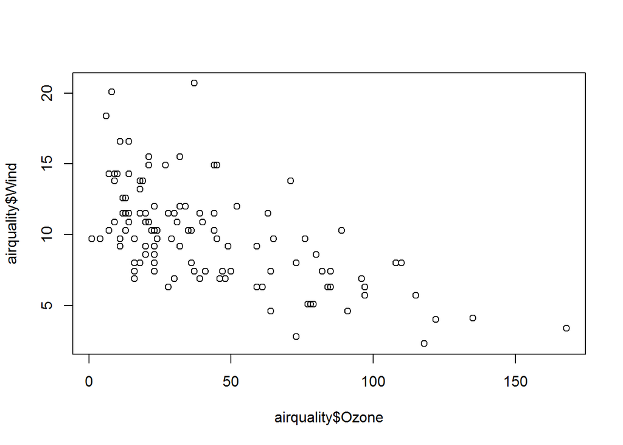

```r
plot(airquality$Wind~airquality$Ozone)
```

# Exercise 3

*Compare the AIC of the three models above mod1, mod2, and mod3. Do you have different conclusion in terms of which model performs better?*

```r
AIC(mod1, mod2, mod3)
```

```
##      df      AIC
## mod1  3 788.9671
## mod2  4 782.6779
## mod3  5 747.5795
```

According to the AIC test, including Ozone in model 3 shows a significant improvement over model 2, since the AIC reductions is roughly 35, much more than 10. Based on the change in coefficients observed in Exercise 2, I questioned whether model 3 was an improvement. AIC convinces me that is is.